# Risk Factor Analysis

## Outcome Variable

**Outcome Variable:** ever_stunted

## Predictor Variables

**Intervention Variable:** fage

**Adjustment Set:**

- arm
- W_mage
- meducyrs
- feducyrs
- W_mhtcm
- W_mwtkg
- W_mbmi
- W_fhtcm
- single
- brthmon
- delta_W_mage
- delta_meducyrs
- delta_feducyrs
- delta_W_mhtcm
- delta_W_mwtkg
- delta_W_mbmi
- delta_W_fhtcm
- delta_single
- delta_brthmon

## Stratifying Variables

The analysis was stratified on these variable(s):

- agecat
- studyid
- country

## Data Summary

| agecat | studyid | country | fage | ever_stunted | n_cell | n |
| --- | --- | --- | --- | --- | --- | --- |
| 0-6 months | ki0047075b-MAL-ED | BANGLADESH | >=35 | 0 | 86 | 151 |
| 0-6 months | ki0047075b-MAL-ED | BANGLADESH | >=35 | 1 | 16 | 151 |
| 0-6 months | ki0047075b-MAL-ED | BANGLADESH | [25-30) | 0 | 11 | 151 |
| 0-6 months | ki0047075b-MAL-ED | BANGLADESH | [25-30) | 1 | 3 | 151 |
| 0-6 months | ki0047075b-MAL-ED | BANGLADESH | [30-35) | 0 | 33 | 151 |
| 0-6 months | ki0047075b-MAL-ED | BANGLADESH | [30-35) | 1 | 2 | 151 |
| 0-6 months | ki0047075b-MAL-ED | BRAZIL | >=35 | 0 | 36 | 79 |
| 0-6 months | ki0047075b-MAL-ED | BRAZIL | >=35 | 1 | 4 | 79 |
| 0-6 months | ki0047075b-MAL-ED | BRAZIL | <25 | 0 | 3 | 79 |
| 0-6 months | ki0047075b-MAL-ED | BRAZIL | <25 | 1 | 0 | 79 |
| 0-6 months | ki0047075b-MAL-ED | BRAZIL | [25-30) | 0 | 8 | 79 |
| 0-6 months | ki0047075b-MAL-ED | BRAZIL | [25-30) | 1 | 0 | 79 |
| 0-6 months | ki0047075b-MAL-ED | BRAZIL | [30-35) | 0 | 23 | 79 |
| 0-6 months | ki0047075b-MAL-ED | BRAZIL | [30-35) | 1 | 5 | 79 |
| 0-6 months | ki0047075b-MAL-ED | INDIA | >=35 | 0 | 63 | 161 |
| 0-6 months | ki0047075b-MAL-ED | INDIA | >=35 | 1 | 8 | 161 |
| 0-6 months | ki0047075b-MAL-ED | INDIA | <25 | 0 | 3 | 161 |
| 0-6 months | ki0047075b-MAL-ED | INDIA | <25 | 1 | 0 | 161 |
| 0-6 months | ki0047075b-MAL-ED | INDIA | [25-30) | 0 | 23 | 161 |
| 0-6 months | ki0047075b-MAL-ED | INDIA | [25-30) | 1 | 4 | 161 |
| 0-6 months | ki0047075b-MAL-ED | INDIA | [30-35) | 0 | 47 | 161 |
| 0-6 months | ki0047075b-MAL-ED | INDIA | [30-35) | 1 | 13 | 161 |
| 0-6 months | ki0047075b-MAL-ED | NEPAL | >=35 | 0 | 35 | 79 |
| 0-6 months | ki0047075b-MAL-ED | NEPAL | >=35 | 1 | 3 | 79 |
| 0-6 months | ki0047075b-MAL-ED | NEPAL | [25-30) | 0 | 9 | 79 |
| 0-6 months | ki0047075b-MAL-ED | NEPAL | [25-30) | 1 | 1 | 79 |
| 0-6 months | ki0047075b-MAL-ED | NEPAL | [30-35) | 0 | 27 | 79 |
| 0-6 months | ki0047075b-MAL-ED | NEPAL | [30-35) | 1 | 4 | 79 |
| 0-6 months | ki0047075b-MAL-ED | PERU | >=35 | 0 | 42 | 85 |
| 0-6 months | ki0047075b-MAL-ED | PERU | >=35 | 1 | 3 | 85 |

[output cut: 268 more lines]

The following strata were considered:

- agecat: 0-24 months, studyid: ki0047075b-MAL-ED, country: BANGLADESH
- agecat: 0-24 months, studyid: ki0047075b-MAL-ED, country: BRAZIL
- agecat: 0-24 months, studyid: ki0047075b-MAL-ED, country: INDIA
- agecat: 0-24 months, studyid: ki0047075b-MAL-ED, country: NEPAL
- agecat: 0-24 months, studyid: ki0047075b-MAL-ED, country: PERU
- agecat: 0-24 months, studyid: ki0047075b-MAL-ED, country: SOUTH AFRICA
- agecat: 0-24 months, studyid: ki0047075b-MAL-ED, country: TANZANIA, UNITED REPUBLIC OF
- agecat: 0-24 months, studyid: ki1000304b-SAS-CompFeed, country: INDIA
- agecat: 0-24 months, studyid: ki1000304b-SAS-FoodSuppl, country: INDIA
- agecat: 0-24 months, studyid: ki1119695-PROBIT, country: BELARUS
- agecat: 0-24 months, studyid: ki1135781-COHORTS, country: GUATEMALA
- agecat: 0-24 months, studyid: ki1135781-COHORTS, country: PHILIPPINES
- agecat: 0-24 months, studyid: ki1148112-LCNI-5, country: MALAWI
- agecat: 0-6 months, studyid: ki0047075b-MAL-ED, country: BANGLADESH
- agecat: 0-6 months, studyid: ki0047075b-MAL-ED, country: BRAZIL
- agecat: 0-6 months, studyid: ki0047075b-MAL-ED, country: INDIA
- agecat: 0-6 months, studyid: ki0047075b-MAL-ED, country: NEPAL
- agecat: 0-6 months, studyid: ki0047075b-MAL-ED, country: PERU
- agecat: 0-6 months, studyid: ki0047075b-MAL-ED, country: SOUTH AFRICA
- agecat: 0-6 months, studyid: ki0047075b-MAL-ED, country: TANZANIA, UNITED REPUBLIC OF
- agecat: 0-6 months, studyid: ki1000304b-SAS-CompFeed, country: INDIA
- agecat: 0-6 months, studyid: ki1000304b-SAS-FoodSuppl, country: INDIA
- agecat: 0-6 months, studyid: ki1119695-PROBIT, country: BELARUS
- agecat: 0-6 months, studyid: ki1135781-COHORTS, country: GUATEMALA
- agecat: 0-6 months, studyid: ki1135781-COHORTS, country: PHILIPPINES
- agecat: 0-6 months, studyid: ki1148112-LCNI-5, country: MALAWI
- agecat: 6-24 months, studyid: ki0047075b-MAL-ED, country: BANGLADESH
- agecat: 6-24 months, studyid: ki0047075b-MAL-ED, country: BRAZIL
- agecat: 6-24 months, studyid: ki0047075b-MAL-ED, country: INDIA
- agecat: 6-24 months, studyid: ki0047075b-MAL-ED, country: NEPAL
- agecat: 6-24 months, studyid: ki0047075b-MAL-ED, country: PERU
- agecat: 6-24 months, studyid: ki0047075b-MAL-ED, country: SOUTH AFRICA
- agecat: 6-24 months, studyid: ki0047075b-MAL-ED, country: TANZANIA, UNITED REPUBLIC OF
- agecat: 6-24 months, studyid: ki1000304b-SAS-CompFeed, country: INDIA
- agecat: 6-24 months, studyid: ki1000304b-SAS-FoodSuppl, country: INDIA
- agecat: 6-24 months, studyid: ki1119695-PROBIT, country: BELARUS
- agecat: 6-24 months, studyid: ki1135781-COHORTS, country: GUATEMALA
- agecat: 6-24 months, studyid: ki1135781-COHORTS, country: PHILIPPINES
- agecat: 6-24 months, studyid: ki1148112-LCNI-5, country: MALAWI

### Dropped Strata

Some strata were dropped due to rare outcomes:

- agecat: 0-6 months, studyid: ki0047075b-MAL-ED, country: BANGLADESH
- agecat: 0-6 months, studyid: ki0047075b-MAL-ED, country: BRAZIL
- agecat: 0-6 months, studyid: ki0047075b-MAL-ED, country: INDIA
- agecat: 0-6 months, studyid: ki0047075b-MAL-ED, country: NEPAL
- agecat: 0-6 months, studyid: ki0047075b-MAL-ED, country: PERU
- agecat: 0-6 months, studyid: ki0047075b-MAL-ED, country: SOUTH AFRICA
- agecat: 0-6 months, studyid: ki0047075b-MAL-ED, country: TANZANIA, UNITED REPUBLIC OF
- agecat: 0-6 months, studyid: ki1148112-LCNI-5, country: MALAWI
- agecat: 6-24 months, studyid: ki0047075b-MAL-ED, country: BANGLADESH
- agecat: 6-24 months, studyid: ki0047075b-MAL-ED, country: BRAZIL
- agecat: 6-24 months, studyid: ki0047075b-MAL-ED, country: INDIA
- agecat: 6-24 months, studyid: ki0047075b-MAL-ED, country: NEPAL
- agecat: 6-24 months, studyid: ki0047075b-MAL-ED, country: PERU
- agecat: 6-24 months, studyid: ki0047075b-MAL-ED, country: SOUTH AFRICA
- agecat: 6-24 months, studyid: ki0047075b-MAL-ED, country: TANZANIA, UNITED REPUBLIC OF
- agecat: 6-24 months, studyid: ki1148112-LCNI-5, country: MALAWI
- agecat: 0-24 months, studyid: ki0047075b-MAL-ED, country: BRAZIL
- agecat: 0-24 months, studyid: ki0047075b-MAL-ED, country: INDIA
- agecat: 0-24 months, studyid: ki0047075b-MAL-ED, country: NEPAL
- agecat: 0-24 months, studyid: ki0047075b-MAL-ED, country: PERU
- agecat: 0-24 months, studyid: ki0047075b-MAL-ED, country: SOUTH AFRICA
- agecat: 0-24 months, studyid: ki0047075b-MAL-ED, country: TANZANIA, UNITED REPUBLIC OF

## Methods Detail

We’re interested in the causal parameters $E[Y_a]$ for all values of $a \in \mathcal{A}$. These parameters represent the mean outcome if, possibly contrary to fact, we intervened to set all units to have $A=a$. Under the randomization and positivity assumptions, these are identified by the statistical parameters $\psi_a=E_W[E_{Y|A,W}(Y|A=a,W)]$. In addition, we’re interested in the mean of $Y$, $E[Y]$ under no intervention (the observed mean). We will estimate these parameters by using SuperLearner to fit the relevant likelihood factors – $E_{Y|A,W}(Y|A=a,W)$ and $p(A=a|W)$, and then updating our likelihood fit using a joint TMLE.

For unadjusted analyses ($W=\{\}$), initial likelihoods were estimated using Lrnr_glm to estimate the simple $E(Y|A)$ and Lrnr_mean to estimate $p(A)$. For adjusted analyses, a small library containing Lrnr_glmnet, Lrnr_xgboost, and Lrnr_mean was used.

Having estimated these parameters, we will then use the delta method to estimate relative risks and attributable risks relative to a prespecified baseline level of $A$.

[output not shown]

# Results Detail

## Results Plots

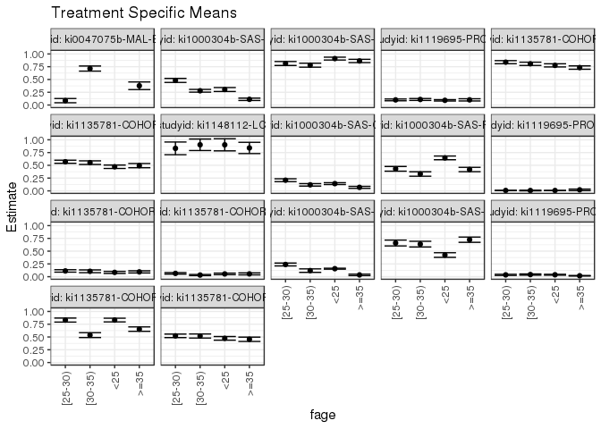

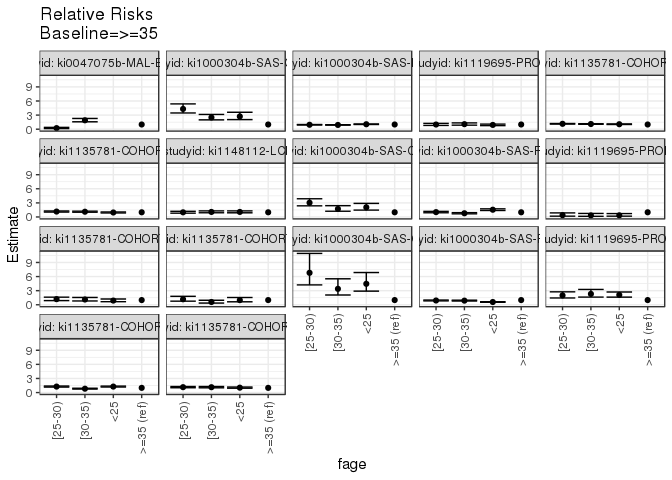

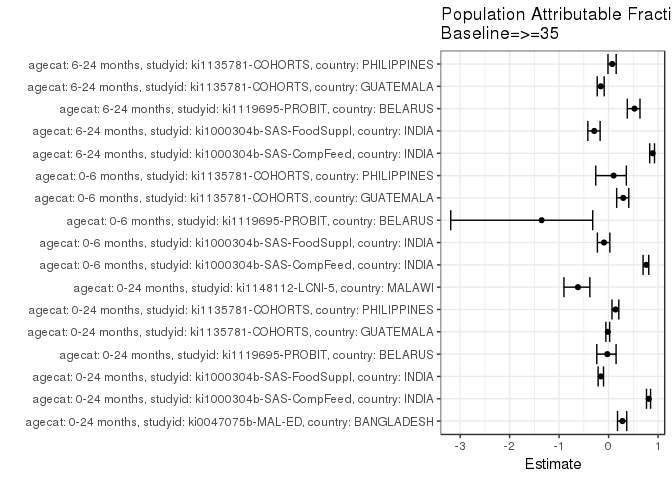

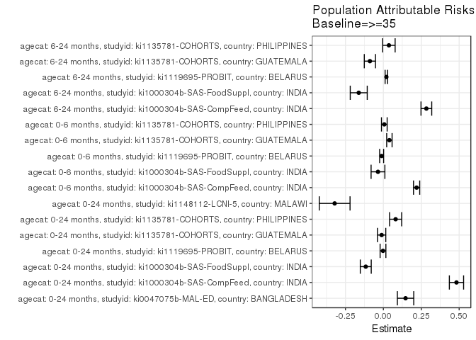

## Results Table

### Parameter: TSM

| agecat | studyid | country | intervention_level | baseline_level | estimate | ci_lower | ci_upper |
| --- | --- | --- | --- | --- | --- | --- | --- |
| 0-24 months | ki0047075b-MAL-ED | BANGLADESH | >=35 | NA | 0.3768433 | 0.3023971 | 0.4512896 |
| 0-24 months | ki0047075b-MAL-ED | BANGLADESH | [25-30) | NA | 0.0858751 | 0.0448332 | 0.1269170 |
| 0-24 months | ki0047075b-MAL-ED | BANGLADESH | [30-35) | NA | 0.7135034 | 0.6635098 | 0.7634970 |
| 0-24 months | ki1000304b-SAS-CompFeed | INDIA | >=35 | NA | 0.1117904 | 0.0888042 | 0.1347767 |
| 0-24 months | ki1000304b-SAS-CompFeed | INDIA | <25 | NA | 0.3033363 | 0.2647037 | 0.3419690 |
| 0-24 months | ki1000304b-SAS-CompFeed | INDIA | [25-30) | NA | 0.4816823 | 0.4426076 | 0.5207570 |
| 0-24 months | ki1000304b-SAS-CompFeed | INDIA | [30-35) | NA | 0.2789687 | 0.2519068 | 0.3060305 |
| 0-24 months | ki1000304b-SAS-FoodSuppl | INDIA | >=35 | NA | 0.8626078 | 0.8303204 | 0.8948953 |
| 0-24 months | ki1000304b-SAS-FoodSuppl | INDIA | <25 | NA | 0.9087770 | 0.8805360 | 0.9370179 |
| 0-24 months | ki1000304b-SAS-FoodSuppl | INDIA | [25-30) | NA | 0.8125555 | 0.7738947 | 0.8512162 |
| 0-24 months | ki1000304b-SAS-FoodSuppl | INDIA | [30-35) | NA | 0.7799996 | 0.7410306 | 0.8189686 |
| 0-24 months | ki1119695-PROBIT | BELARUS | >=35 | NA | 0.1011896 | 0.0795967 | 0.1227825 |
| 0-24 months | ki1119695-PROBIT | BELARUS | <25 | NA | 0.0919844 | 0.0787463 | 0.1052226 |
| 0-24 months | ki1119695-PROBIT | BELARUS | [25-30) | NA | 0.1004692 | 0.0832125 | 0.1177260 |
| 0-24 months | ki1119695-PROBIT | BELARUS | [30-35) | NA | 0.1084947 | 0.0900682 | 0.1269212 |
| 0-24 months | ki1135781-COHORTS | GUATEMALA | >=35 | NA | 0.7332369 | 0.7005294 | 0.7659445 |
| 0-24 months | ki1135781-COHORTS | GUATEMALA | <25 | NA | 0.7762551 | 0.7455862 | 0.8069241 |
| 0-24 months | ki1135781-COHORTS | GUATEMALA | [25-30) | NA | 0.8387335 | 0.8086349 | 0.8688320 |
| 0-24 months | ki1135781-COHORTS | GUATEMALA | [30-35) | NA | 0.8070452 | 0.7750203 | 0.8390701 |
| 0-24 months | ki1135781-COHORTS | PHILIPPINES | >=35 | NA | 0.4939146 | 0.4526537 | 0.5351755 |
| 0-24 months | ki1135781-COHORTS | PHILIPPINES | <25 | NA | 0.4714949 | 0.4378804 | 0.5051094 |
| 0-24 months | ki1135781-COHORTS | PHILIPPINES | [25-30) | NA | 0.5696763 | 0.5390228 | 0.6003299 |
| 0-24 months | ki1135781-COHORTS | PHILIPPINES | [30-35) | NA | 0.5522045 | 0.5170440 | 0.5873650 |
| 0-24 months | ki1148112-LCNI-5 | MALAWI | >=35 | NA | 0.8402373 | 0.7299583 | 0.9505163 |
| 0-24 months | ki1148112-LCNI-5 | MALAWI | <25 | NA | 0.9013231 | 0.7827595 | 1.0198866 |
| 0-24 months | ki1148112-LCNI-5 | MALAWI | [25-30) | NA | 0.8317959 | 0.7077701 | 0.9558217 |
| 0-24 months | ki1148112-LCNI-5 | MALAWI | [30-35) | NA | 0.9020885 | 0.7891525 | 1.0150244 |
| 0-6 months | ki1000304b-SAS-CompFeed | INDIA | >=35 | NA | 0.0687978 | 0.0490634 | 0.0885322 |
| 0-6 months | ki1000304b-SAS-CompFeed | INDIA | <25 | NA | 0.1414633 | 0.1232511 | 0.1596755 |
| 0-6 months | ki1000304b-SAS-CompFeed | INDIA | [25-30) | NA | 0.2085045 | 0.1807707 | 0.2362383 |
| 0-6 months | ki1000304b-SAS-CompFeed | INDIA | [30-35) | NA | 0.1178539 | 0.0935720 | 0.1421357 |
| 0-6 months | ki1000304b-SAS-FoodSuppl | INDIA | >=35 | NA | 0.4177489 | 0.3749494 | 0.4605484 |
| 0-6 months | ki1000304b-SAS-FoodSuppl | INDIA | <25 | NA | 0.6454257 | 0.6091467 | 0.6817048 |
| 0-6 months | ki1000304b-SAS-FoodSuppl | INDIA | [25-30) | NA | 0.4313204 | 0.3853043 | 0.4773365 |
| 0-6 months | ki1000304b-SAS-FoodSuppl | INDIA | [30-35) | NA | 0.3301511 | 0.2868780 | 0.3734243 |
| 0-6 months | ki1119695-PROBIT | BELARUS | >=35 | NA | 0.0198072 | 0.0047615 | 0.0348529 |
| 0-6 months | ki1119695-PROBIT | BELARUS | <25 | NA | 0.0069531 | 0.0045131 | 0.0093932 |
| 0-6 months | ki1119695-PROBIT | BELARUS | [25-30) | NA | 0.0077551 | 0.0040221 | 0.0114881 |
| 0-6 months | ki1119695-PROBIT | BELARUS | [30-35) | NA | 0.0066169 | 0.0013040 | 0.0119298 |
| 0-6 months | ki1135781-COHORTS | GUATEMALA | >=35 | NA | 0.0943239 | 0.0732028 | 0.1154449 |
| 0-6 months | ki1135781-COHORTS | GUATEMALA | <25 | NA | 0.0842824 | 0.0641116 | 0.1044531 |
| 0-6 months | ki1135781-COHORTS | GUATEMALA | [25-30) | NA | 0.1130523 | 0.0891218 | 0.1369829 |
| 0-6 months | ki1135781-COHORTS | GUATEMALA | [30-35) | NA | 0.1055676 | 0.0785027 | 0.1326326 |
| 0-6 months | ki1135781-COHORTS | PHILIPPINES | >=35 | NA | 0.0551262 | 0.0357390 | 0.0745135 |
| 0-6 months | ki1135781-COHORTS | PHILIPPINES | <25 | NA | 0.0544673 | 0.0391949 | 0.0697397 |
| 0-6 months | ki1135781-COHORTS | PHILIPPINES | [25-30) | NA | 0.0646610 | 0.0491570 | 0.0801649 |
| 0-6 months | ki1135781-COHORTS | PHILIPPINES | [30-35) | NA | 0.0325261 | 0.0215512 | 0.0435011 |
| 6-24 months | ki1000304b-SAS-CompFeed | INDIA | >=35 | NA | 0.0351431 | 0.0210270 | 0.0492591 |
| 6-24 months | ki1000304b-SAS-CompFeed | INDIA | <25 | NA | 0.1567598 | 0.1478081 | 0.1657115 |
| 6-24 months | ki1000304b-SAS-CompFeed | INDIA | [25-30) | NA | 0.2390027 | 0.2109611 | 0.2670442 |
| 6-24 months | ki1000304b-SAS-CompFeed | INDIA | [30-35) | NA | 0.1191025 | 0.0848252 | 0.1533798 |
| 6-24 months | ki1000304b-SAS-FoodSuppl | INDIA | >=35 | NA | 0.7243955 | 0.6728975 | 0.7758935 |
| 6-24 months | ki1000304b-SAS-FoodSuppl | INDIA | <25 | NA | 0.4242964 | 0.3789862 | 0.4696066 |
| 6-24 months | ki1000304b-SAS-FoodSuppl | INDIA | [25-30) | NA | 0.6592440 | 0.6018716 | 0.7166164 |
| 6-24 months | ki1000304b-SAS-FoodSuppl | INDIA | [30-35) | NA | 0.6373067 | 0.5816511 | 0.6929624 |
| 6-24 months | ki1119695-PROBIT | BELARUS | >=35 | NA | 0.0180713 | 0.0131332 | 0.0230094 |
| 6-24 months | ki1119695-PROBIT | BELARUS | <25 | NA | 0.0379900 | 0.0294886 | 0.0464915 |
| 6-24 months | ki1119695-PROBIT | BELARUS | [25-30) | NA | 0.0360407 | 0.0250599 | 0.0470214 |
| 6-24 months | ki1119695-PROBIT | BELARUS | [30-35) | NA | 0.0417013 | 0.0300510 | 0.0533516 |
| 6-24 months | ki1135781-COHORTS | GUATEMALA | >=35 | NA | 0.6539403 | 0.6107444 | 0.6971363 |
| 6-24 months | ki1135781-COHORTS | GUATEMALA | <25 | NA | 0.8316020 | 0.7956998 | 0.8675042 |
| 6-24 months | ki1135781-COHORTS | GUATEMALA | [25-30) | NA | 0.8311818 | 0.7917674 | 0.8705963 |
| 6-24 months | ki1135781-COHORTS | GUATEMALA | [30-35) | NA | 0.5367002 | 0.4893315 | 0.5840688 |
| 6-24 months | ki1135781-COHORTS | PHILIPPINES | >=35 | NA | 0.4552977 | 0.4131972 | 0.4973982 |
| 6-24 months | ki1135781-COHORTS | PHILIPPINES | <25 | NA | 0.4735425 | 0.4380887 | 0.5089964 |
| 6-24 months | ki1135781-COHORTS | PHILIPPINES | [25-30) | NA | 0.5223202 | 0.4878919 | 0.5567486 |
| 6-24 months | ki1135781-COHORTS | PHILIPPINES | [30-35) | NA | 0.5189592 | 0.4793587 | 0.5585597 |

### Parameter: E(Y)

| agecat | studyid | country | intervention_level | baseline_level | estimate | ci_lower | ci_upper |
| --- | --- | --- | --- | --- | --- | --- | --- |
| 0-24 months | ki0047075b-MAL-ED | BANGLADESH | NA | NA | 0.5231788 | 0.4432496 | 0.6031080 |
| 0-24 months | ki1000304b-SAS-CompFeed | INDIA | NA | NA | 0.5941176 | 0.5531511 | 0.6350842 |
| 0-24 months | ki1000304b-SAS-FoodSuppl | INDIA | NA | NA | 0.7464115 | 0.7046540 | 0.7881689 |
| 0-24 months | ki1119695-PROBIT | BELARUS | NA | NA | 0.0987283 | 0.0829150 | 0.1145416 |
| 0-24 months | ki1135781-COHORTS | GUATEMALA | NA | NA | 0.7217525 | 0.6973920 | 0.7461130 |
| 0-24 months | ki1135781-COHORTS | PHILIPPINES | NA | NA | 0.5747204 | 0.5568801 | 0.5925608 |
| 0-24 months | ki1148112-LCNI-5 | MALAWI | NA | NA | 0.5188679 | 0.4232996 | 0.6144363 |
| 0-6 months | ki1000304b-SAS-CompFeed | INDIA | NA | NA | 0.2881467 | 0.2614090 | 0.3148844 |
| 0-6 months | ki1000304b-SAS-FoodSuppl | INDIA | NA | NA | 0.3822115 | 0.3354600 | 0.4289631 |
| 0-6 months | ki1119695-PROBIT | BELARUS | NA | NA | 0.0084189 | 0.0052961 | 0.0115416 |
| 0-6 months | ki1135781-COHORTS | GUATEMALA | NA | NA | 0.1340304 | 0.1134336 | 0.1546272 |
| 0-6 months | ki1135781-COHORTS | PHILIPPINES | NA | NA | 0.0613351 | 0.0526766 | 0.0699937 |
| 6-24 months | ki1000304b-SAS-CompFeed | INDIA | NA | NA | 0.3187954 | 0.2885259 | 0.3490649 |
| 6-24 months | ki1000304b-SAS-FoodSuppl | INDIA | NA | NA | 0.5619469 | 0.4971181 | 0.6267757 |
| 6-24 months | ki1119695-PROBIT | BELARUS | NA | NA | 0.0379159 | 0.0282938 | 0.0475380 |
| 6-24 months | ki1135781-COHORTS | GUATEMALA | NA | NA | 0.5650741 | 0.5256037 | 0.6045446 |
| 6-24 months | ki1135781-COHORTS | PHILIPPINES | NA | NA | 0.4918567 | 0.4707148 | 0.5129985 |

### Parameter: RR

| agecat | studyid | country | intervention_level | baseline_level | estimate | ci_lower | ci_upper |
| --- | --- | --- | --- | --- | --- | --- | --- |
| 0-24 months | ki0047075b-MAL-ED | BANGLADESH | >=35 | >=35 | 1.0000000 | 1.0000000 | 1.0000000 |
| 0-24 months | ki0047075b-MAL-ED | BANGLADESH | [25-30) | >=35 | 0.2278802 | 0.1338349 | 0.3880107 |
| 0-24 months | ki0047075b-MAL-ED | BANGLADESH | [30-35) | >=35 | 1.8933689 | 1.5718807 | 2.2806092 |
| 0-24 months | ki1000304b-SAS-CompFeed | INDIA | >=35 | >=35 | 1.0000000 | 1.0000000 | 1.0000000 |
| 0-24 months | ki1000304b-SAS-CompFeed | INDIA | <25 | >=35 | 2.7134375 | 2.0433355 | 3.6032962 |
| 0-24 months | ki1000304b-SAS-CompFeed | INDIA | [25-30) | >=35 | 4.3087973 | 3.4524419 | 5.3775661 |
| 0-24 months | ki1000304b-SAS-CompFeed | INDIA | [30-35) | >=35 | 2.4954613 | 1.9842750 | 3.1383386 |
| 0-24 months | ki1000304b-SAS-FoodSuppl | INDIA | >=35 | >=35 | 1.0000000 | 1.0000000 | 1.0000000 |
| 0-24 months | ki1000304b-SAS-FoodSuppl | INDIA | <25 | >=35 | 1.0535228 | 1.0041253 | 1.1053502 |
| 0-24 months | ki1000304b-SAS-FoodSuppl | INDIA | [25-30) | >=35 | 0.9419755 | 0.8907820 | 0.9961112 |
| 0-24 months | ki1000304b-SAS-FoodSuppl | INDIA | [30-35) | >=35 | 0.9042343 | 0.8545989 | 0.9567526 |
| 0-24 months | ki1119695-PROBIT | BELARUS | >=35 | >=35 | 1.0000000 | 1.0000000 | 1.0000000 |
| 0-24 months | ki1119695-PROBIT | BELARUS | <25 | >=35 | 0.9090303 | 0.7655934 | 1.0793407 |
| 0-24 months | ki1119695-PROBIT | BELARUS | [25-30) | >=35 | 0.9928808 | 0.7959251 | 1.2385743 |
| 0-24 months | ki1119695-PROBIT | BELARUS | [30-35) | >=35 | 1.0721920 | 0.8588086 | 1.3385935 |
| 0-24 months | ki1135781-COHORTS | GUATEMALA | >=35 | >=35 | 1.0000000 | 1.0000000 | 1.0000000 |
| 0-24 months | ki1135781-COHORTS | GUATEMALA | <25 | >=35 | 1.0586689 | 0.9989051 | 1.1220083 |
| 0-24 months | ki1135781-COHORTS | GUATEMALA | [25-30) | >=35 | 1.1438778 | 1.0812500 | 1.2101332 |
| 0-24 months | ki1135781-COHORTS | GUATEMALA | [30-35) | >=35 | 1.1006609 | 1.0385048 | 1.1665371 |
| 0-24 months | ki1135781-COHORTS | PHILIPPINES | >=35 | >=35 | 1.0000000 | 1.0000000 | 1.0000000 |
| 0-24 months | ki1135781-COHORTS | PHILIPPINES | <25 | >=35 | 0.9546082 | 0.8554310 | 1.0652838 |
| 0-24 months | ki1135781-COHORTS | PHILIPPINES | [25-30) | >=35 | 1.1533904 | 1.0449811 | 1.2730464 |
| 0-24 months | ki1135781-COHORTS | PHILIPPINES | [30-35) | >=35 | 1.1180162 | 1.0074196 | 1.2407542 |
| 0-24 months | ki1148112-LCNI-5 | MALAWI | >=35 | >=35 | 1.0000000 | 1.0000000 | 1.0000000 |
| 0-24 months | ki1148112-LCNI-5 | MALAWI | <25 | >=35 | 1.0727006 | 0.8886570 | 1.2948601 |
| 0-24 months | ki1148112-LCNI-5 | MALAWI | [25-30) | >=35 | 0.9899536 | 0.8090828 | 1.2112581 |
| 0-24 months | ki1148112-LCNI-5 | MALAWI | [30-35) | >=35 | 1.0736115 | 0.8934352 | 1.2901235 |
| 0-6 months | ki1000304b-SAS-CompFeed | INDIA | >=35 | >=35 | 1.0000000 | 1.0000000 | 1.0000000 |
| 0-6 months | ki1000304b-SAS-CompFeed | INDIA | <25 | >=35 | 2.0562194 | 1.4617979 | 2.8923548 |
| 0-6 months | ki1000304b-SAS-CompFeed | INDIA | [25-30) | >=35 | 3.0306869 | 2.3721498 | 3.8720417 |
| 0-6 months | ki1000304b-SAS-CompFeed | INDIA | [30-35) | >=35 | 1.7130479 | 1.2191785 | 2.4069758 |
| 0-6 months | ki1000304b-SAS-FoodSuppl | INDIA | >=35 | >=35 | 1.0000000 | 1.0000000 | 1.0000000 |
| 0-6 months | ki1000304b-SAS-FoodSuppl | INDIA | <25 | >=35 | 1.5450088 | 1.3768797 | 1.7336681 |
| 0-6 months | ki1000304b-SAS-FoodSuppl | INDIA | [25-30) | >=35 | 1.0324873 | 0.8936999 | 1.1928277 |
| 0-6 months | ki1000304b-SAS-FoodSuppl | INDIA | [30-35) | >=35 | 0.7903100 | 0.6723531 | 0.9289612 |
| 0-6 months | ki1119695-PROBIT | BELARUS | >=35 | >=35 | 1.0000000 | 1.0000000 | 1.0000000 |
| 0-6 months | ki1119695-PROBIT | BELARUS | <25 | >=35 | 0.3510406 | 0.1689958 | 0.7291865 |
| 0-6 months | ki1119695-PROBIT | BELARUS | [25-30) | >=35 | 0.3915282 | 0.1768072 | 0.8670144 |
| 0-6 months | ki1119695-PROBIT | BELARUS | [30-35) | >=35 | 0.3340641 | 0.1473064 | 0.7575965 |
| 0-6 months | ki1135781-COHORTS | GUATEMALA | >=35 | >=35 | 1.0000000 | 1.0000000 | 1.0000000 |
| 0-6 months | ki1135781-COHORTS | GUATEMALA | <25 | >=35 | 0.8935423 | 0.6498358 | 1.2286455 |
| 0-6 months | ki1135781-COHORTS | GUATEMALA | [25-30) | >=35 | 1.1985549 | 0.8894323 | 1.6151132 |
| 0-6 months | ki1135781-COHORTS | GUATEMALA | [30-35) | >=35 | 1.1192039 | 0.8048018 | 1.5564297 |
| 0-6 months | ki1135781-COHORTS | PHILIPPINES | >=35 | >=35 | 1.0000000 | 1.0000000 | 1.0000000 |
| 0-6 months | ki1135781-COHORTS | PHILIPPINES | <25 | >=35 | 0.9880465 | 0.6304706 | 1.5484240 |
| 0-6 months | ki1135781-COHORTS | PHILIPPINES | [25-30) | >=35 | 1.1729617 | 0.7673097 | 1.7930688 |
| 0-6 months | ki1135781-COHORTS | PHILIPPINES | [30-35) | >=35 | 0.5900299 | 0.3629487 | 0.9591858 |
| 6-24 months | ki1000304b-SAS-CompFeed | INDIA | >=35 | >=35 | 1.0000000 | 1.0000000 | 1.0000000 |
| 6-24 months | ki1000304b-SAS-CompFeed | INDIA | <25 | >=35 | 4.4606176 | 2.9011537 | 6.8583438 |
| 6-24 months | ki1000304b-SAS-CompFeed | INDIA | [25-30) | >=35 | 6.8008477 | 4.2328502 | 10.9268054 |
| 6-24 months | ki1000304b-SAS-CompFeed | INDIA | [30-35) | >=35 | 3.3890739 | 2.0786863 | 5.5255196 |
| 6-24 months | ki1000304b-SAS-FoodSuppl | INDIA | >=35 | >=35 | 1.0000000 | 1.0000000 | 1.0000000 |
| 6-24 months | ki1000304b-SAS-FoodSuppl | INDIA | <25 | >=35 | 0.5857248 | 0.5216893 | 0.6576204 |
| 6-24 months | ki1000304b-SAS-FoodSuppl | INDIA | [25-30) | >=35 | 0.9100608 | 0.8205412 | 1.0093469 |
| 6-24 months | ki1000304b-SAS-FoodSuppl | INDIA | [30-35) | >=35 | 0.8797773 | 0.7942278 | 0.9745417 |
| 6-24 months | ki1119695-PROBIT | BELARUS | >=35 | >=35 | 1.0000000 | 1.0000000 | 1.0000000 |
| 6-24 months | ki1119695-PROBIT | BELARUS | <25 | >=35 | 2.1022294 | 1.6271781 | 2.7159710 |
| 6-24 months | ki1119695-PROBIT | BELARUS | [25-30) | >=35 | 1.9943604 | 1.4446020 | 2.7533351 |
| 6-24 months | ki1119695-PROBIT | BELARUS | [30-35) | >=35 | 2.3075987 | 1.6337519 | 3.2593760 |
| 6-24 months | ki1135781-COHORTS | GUATEMALA | >=35 | >=35 | 1.0000000 | 1.0000000 | 1.0000000 |
| 6-24 months | ki1135781-COHORTS | GUATEMALA | <25 | >=35 | 1.2716787 | 1.1738710 | 1.3776358 |
| 6-24 months | ki1135781-COHORTS | GUATEMALA | [25-30) | >=35 | 1.2710362 | 1.1706804 | 1.3799949 |
| 6-24 months | ki1135781-COHORTS | GUATEMALA | [30-35) | >=35 | 0.8207174 | 0.7372197 | 0.9136720 |
| 6-24 months | ki1135781-COHORTS | PHILIPPINES | >=35 | >=35 | 1.0000000 | 1.0000000 | 1.0000000 |
| 6-24 months | ki1135781-COHORTS | PHILIPPINES | <25 | >=35 | 1.0400724 | 0.9241780 | 1.1705002 |
| 6-24 months | ki1135781-COHORTS | PHILIPPINES | [25-30) | >=35 | 1.1472060 | 1.0250707 | 1.2838936 |
| 6-24 months | ki1135781-COHORTS | PHILIPPINES | [30-35) | >=35 | 1.1398240 | 1.0119894 | 1.2838066 |

### Parameter: PAR

| agecat | studyid | country | intervention_level | baseline_level | estimate | ci_lower | ci_upper |
| --- | --- | --- | --- | --- | --- | --- | --- |
| 0-24 months | ki0047075b-MAL-ED | BANGLADESH | >=35 | NA | 0.1463355 | 0.0922623 | 0.2004086 |
| 0-24 months | ki1000304b-SAS-CompFeed | INDIA | >=35 | NA | 0.4823272 | 0.4353183 | 0.5293362 |
| 0-24 months | ki1000304b-SAS-FoodSuppl | INDIA | >=35 | NA | -0.1161963 | -0.1522959 | -0.0800967 |
| 0-24 months | ki1119695-PROBIT | BELARUS | >=35 | NA | -0.0024614 | -0.0214776 | 0.0165548 |
| 0-24 months | ki1135781-COHORTS | GUATEMALA | >=35 | NA | -0.0114844 | -0.0388419 | 0.0158731 |
| 0-24 months | ki1135781-COHORTS | PHILIPPINES | >=35 | NA | 0.0808058 | 0.0409334 | 0.1206783 |
| 0-24 months | ki1148112-LCNI-5 | MALAWI | >=35 | NA | -0.3213694 | -0.4229136 | -0.2198251 |
| 0-6 months | ki1000304b-SAS-CompFeed | INDIA | >=35 | NA | 0.2193489 | 0.1989018 | 0.2397961 |
| 0-6 months | ki1000304b-SAS-FoodSuppl | INDIA | >=35 | NA | -0.0355374 | -0.0810396 | 0.0099649 |
| 0-6 months | ki1119695-PROBIT | BELARUS | >=35 | NA | -0.0113884 | -0.0245235 | 0.0017468 |
| 0-6 months | ki1135781-COHORTS | GUATEMALA | >=35 | NA | 0.0397066 | 0.0219556 | 0.0574575 |
| 0-6 months | ki1135781-COHORTS | PHILIPPINES | >=35 | NA | 0.0062089 | -0.0125273 | 0.0249451 |
| 6-24 months | ki1000304b-SAS-CompFeed | INDIA | >=35 | NA | 0.2836524 | 0.2482103 | 0.3190944 |
| 6-24 months | ki1000304b-SAS-FoodSuppl | INDIA | >=35 | NA | -0.1624486 | -0.2184911 | -0.1064061 |
| 6-24 months | ki1119695-PROBIT | BELARUS | >=35 | NA | 0.0198446 | 0.0114784 | 0.0282108 |
| 6-24 months | ki1135781-COHORTS | GUATEMALA | >=35 | NA | -0.0888662 | -0.1258262 | -0.0519062 |
| 6-24 months | ki1135781-COHORTS | PHILIPPINES | >=35 | NA | 0.0365590 | -0.0044601 | 0.0775781 |

### Parameter: PAF

| agecat | studyid | country | intervention_level | baseline_level | estimate | ci_lower | ci_upper |
| --- | --- | --- | --- | --- | --- | --- | --- |
| 0-24 months | ki0047075b-MAL-ED | BANGLADESH | >=35 | NA | 0.2797045 | 0.1803942 | 0.3669816 |
| 0-24 months | ki1000304b-SAS-CompFeed | INDIA | >=35 | NA | 0.8118379 | 0.7662416 | 0.8485403 |
| 0-24 months | ki1000304b-SAS-FoodSuppl | INDIA | >=35 | NA | -0.1556733 | -0.2115246 | -0.1023968 |
| 0-24 months | ki1119695-PROBIT | BELARUS | >=35 | NA | -0.0249307 | -0.2380423 | 0.1514966 |
| 0-24 months | ki1135781-COHORTS | GUATEMALA | >=35 | NA | -0.0159119 | -0.0546497 | 0.0214031 |
| 0-24 months | ki1135781-COHORTS | PHILIPPINES | >=35 | NA | 0.1406003 | 0.0688827 | 0.2067939 |
| 0-24 months | ki1148112-LCNI-5 | MALAWI | >=35 | NA | -0.6193664 | -0.9024597 | -0.3783985 |
| 0-6 months | ki1000304b-SAS-CompFeed | INDIA | >=35 | NA | 0.7612405 | 0.6973199 | 0.8116622 |
| 0-6 months | ki1000304b-SAS-FoodSuppl | INDIA | >=35 | NA | -0.0929782 | -0.2263912 | 0.0259214 |
| 0-6 months | ki1119695-PROBIT | BELARUS | >=35 | NA | -1.3527206 | -3.1905488 | -0.3208996 |
| 0-6 months | ki1135781-COHORTS | GUATEMALA | >=35 | NA | 0.2962503 | 0.1635581 | 0.4078924 |
| 0-6 months | ki1135781-COHORTS | PHILIPPINES | >=35 | NA | 0.1012289 | -0.2599339 | 0.3588636 |
| 6-24 months | ki1000304b-SAS-CompFeed | INDIA | >=35 | NA | 0.8897629 | 0.8309300 | 0.9281232 |
| 6-24 months | ki1000304b-SAS-FoodSuppl | INDIA | >=35 | NA | -0.2890818 | -0.4191391 | -0.1709436 |
| 6-24 months | ki1119695-PROBIT | BELARUS | >=35 | NA | 0.5233845 | 0.3784288 | 0.6345353 |
| 6-24 months | ki1135781-COHORTS | GUATEMALA | >=35 | NA | -0.1572646 | -0.2295760 | -0.0892060 |
| 6-24 months | ki1135781-COHORTS | PHILIPPINES | >=35 | NA | 0.0743286 | -0.0122850 | 0.1535313 |